# Linear Regression

D. Howell

10/19/2020

## Intro

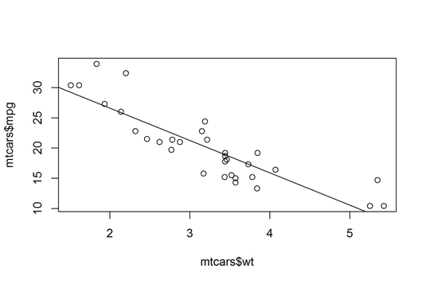

- Multiple vs. Single Linear Regression
- plot shape in Wolfram Alpha
- Model Fitting
- Draw line at minimum error
- Model Input
- Continuous and not discrete
- Model Output
- Continuous (regression)

- Multiple vs. Single Linear Regression
- plot shape in Wolfram Alpha

Model Fitting

- Draw line at minimum error

Model Input

- Continuous and not discrete

Model Output

- Continuous (regression)

## Data Import and Cleaning

> Analysis Question: How well can we predict, using a linear model, county-level political (presidential) leanings given education level and previous levels of voter turnout?

```r
library(readr)

setwd('/Users/drewhowell/Desktop/CSC-201/2020_Fall/20201019_Linear_Models/')

education <- read_csv('education_county.csv')
voted <- read_csv('voted_county.csv')
pops <- read_csv('populations_county.csv')

voted$ID <- paste(voted$county, voted$state_po)
voted <- voted[voted$year == max(voted$year),]
voted$version <- NULL

ids <- unique(voted$ID)


i=2820
for (i in 1:length(ids)){

  temp <- voted[voted$ID == ids[i],]
  if(!F %in% is.na(temp$candidatevotes)){
    next
  }
  temp$spectrum <- (-as.numeric(na.omit((temp$candidatevotes[temp$party=='democrat']/temp$totalvotes[temp$party=='democrat'] *10))) +
    as.numeric(na.omit((temp$candidatevotes[temp$party=='republican']/temp$totalvotes[temp$party=='republican'] *10))))[1]
  x <- temp[temp$candidatevotes == max(temp$candidatevotes),]

  if(i==1){
    clean_voted <- x
  } else {
    clean_voted <- rbind(clean_voted, x)
  }
}

education <- education[!is.na(education$`2003 Rural-urban Continuum Code`),]
education$ed_spectrum <- -(2*education$`Percent of adults with less than a high school diploma, 2014-18` +
  education$`Percent of adults with a high school diploma only, 2014-18`) +
  education$`Percent of adults completing some college or associate's degree, 2014-18` +
  education$`Percent of adults with a bachelor's degree or higher, 2014-18`*2

library(dplyr)
education <- select(education, State, `Area name`, ed_spectrum)
education <- education[-1,]
education$`Area name` <- gsub(' County','', education$`Area name`)
education$ID <- paste(education$`Area name`, education$State)
education$State <- education$`Area name` <- NULL

df <- inner_join(clean_voted, education, by = c('ID' = 'ID'))

pops$CTYNAME <- gsub(' County','', pops$CTYNAME)
for(i in 1:nrow(pops)){
  pops$STNAME[i] <- ifelse(length(state.abb[grep(pops$STNAME[i], state.name)])==0, NA, state.abb[grep(pops$STNAME[i], state.name)])
}
pops$ID <- paste(pops$CTYNAME, pops$STNAME)

pops <- select(pops, ID, POPESTIMATE2019)
pops <- pops[!duplicated(pops$ID),]

df <- inner_join(df, pops)

df$turnout <- df$totalvotes / df$POPESTIMATE2019
df <- df[df$turnout < 1,]
```

## Modelling

```r
mean(df$spectrum)
```

```
## [1] 3.245903
```

```r
sum(df$POPESTIMATE2019 * df$spectrum) / sum(df$POPESTIMATE2019)
```

```
## [1] -0.5163369
```

```r
model <- lm(spectrum ~ turnout + ed_spectrum, df)
model_a <- lm(spectrum ~ turnout, df)
model_b <- lm(spectrum ~ ed_spectrum, df)

library(jtools)
summ(model)
```

[output not shown]

```r
library(readr)

setwd('C:/Users/drew.howell/Desktop/CSC-201/2020_Fall/20201019_Linear_Models/')

education <- read_csv('education_county.csv')
voted <- read_csv('voted_county.csv')
pops <- read_csv('populations_county.csv')

voted$ID <- paste(voted$county, voted$state_po)
voted <- voted[voted$year == max(voted$year),]
voted$version <- NULL

ids <- unique(voted$ID)


i=2820
for (i in 1:length(ids)){

  temp <- voted[voted$ID == ids[i],]
  if(!F %in% is.na(temp$candidatevotes)){
    next
  }
  temp$spectrum <- (-as.numeric(na.omit((temp$candidatevotes[temp$party=='democrat']/temp$totalvotes[temp$party=='democrat'] *10))) +
    as.numeric(na.omit((temp$candidatevotes[temp$party=='republican']/temp$totalvotes[temp$party=='republican'] *10))))[1]
  x <- temp[temp$candidatevotes == max(temp$candidatevotes),]

  if(i==1){
    clean_voted <- x
  } else {
    clean_voted <- rbind(clean_voted, x)
  }
}

education <- education[!is.na(education$`2003 Rural-urban Continuum Code`),]
education$ed_spectrum <- -(2*education$`Percent of adults with less than a high school diploma, 2014-18` +
  education$`Percent of adults with a high school diploma only, 2014-18`) +
  education$`Percent of adults completing some college or associate's degree, 2014-18` +
  education$`Percent of adults with a bachelor's degree or higher, 2014-18`*2

library(dplyr)
education <- select(education, State, `Area name`, ed_spectrum)
education <- education[-1,]
education$`Area name` <- gsub(' County','', education$`Area name`)
education$ID <- paste(education$`Area name`, education$State)
education$State <- education$`Area name` <- NULL

df <- inner_join(clean_voted, education, by = c('ID' = 'ID'))

pops$CTYNAME <- gsub(' County','', pops$CTYNAME)
for(i in 1:nrow(pops)){
  pops$STNAME[i] <- ifelse(length(state.abb[grep(pops$STNAME[i], state.name)])==0, NA, state.abb[grep(pops$STNAME[i], state.name)])
}
pops$ID <- paste(pops$CTYNAME, pops$STNAME)

pops <- select(pops, ID, POPESTIMATE2019)
pops <- pops[!duplicated(pops$ID),]

df <- inner_join(df, pops)

df$turnout <- df$totalvotes / df$POPESTIMATE2019
df <- df[df$turnout < 1,]
```

# Modelling

```r
mean(df$spectrum)
```

```
## [1] 3.245903
```

```r
sum(df$POPESTIMATE2019 * df$spectrum) / sum(df$POPESTIMATE2019)
```

```
## [1] -0.5163369
```

```r
model <- lm(spectrum ~ turnout + ed_spectrum, df)
model_a <- lm(spectrum ~ turnout, df)
model_b <- lm(spectrum ~ ed_spectrum, df)

library(jtools)
summ(model)
```

| Observations | 2997 |
| --- | --- |
| Dependent variable | spectrum |
| Type | OLS linear regression |

| F(2,2994) | 210.73 |
| --- | --- |
| R² | 0.12 |
| Adj. R² | 0.12 |

|  | Est. | S.E. | t val. | p |
| --- | --- | --- | --- | --- |
| (Intercept) | 1.35 | 0.30 | 4.51 | 0.00 |
| turnout | 5.25 | 0.68 | 7.68 | 0.00 |
| ed_spectrum | -0.03 | 0.00 | -20.53 | 0.00 |

Standard errors: OLS

```r
summ(model_a)
```

| Observations | 2997 |
| --- | --- |
| Dependent variable | spectrum |
| Type | OLS linear regression |

| F(1,2995) | 0.05 |
| --- | --- |
| R² | 0.00 |
| Adj. R² | -0.00 |

|  | Est. | S.E. | t val. | p |
| --- | --- | --- | --- | --- |
| (Intercept) | 3.31 | 0.30 | 10.90 | 0.00 |
| turnout | -0.14 | 0.67 | -0.21 | 0.83 |

Standard errors: OLS

```r
summ(model_b)
```

| Observations | 2997 |
| --- | --- |
| Dependent variable | spectrum |
| Type | OLS linear regression |

| F(1,2995) | 355.57 |
| --- | --- |
| R² | 0.11 |
| Adj. R² | 0.11 |

|  | Est. | S.E. | t val. | p |
| --- | --- | --- | --- | --- |
| (Intercept) | 3.61 | 0.06 | 64.80 | 0.00 |
| ed_spectrum | -0.03 | 0.00 | -18.86 | 0.00 |

Standard errors: OLS

### Interpreting the output

- p-value
- measures the significance of your results
- hypothesis testing
- R-squared
- measures how much of the data is explained by your model

- p-value
  - measures the significance of your results
  - hypothesis testing
- R-squared
  - measures how much of the data is explained by your model

## Modelling with Normalized Predictors

```r
normalize <- function(x){
  return((x - min(x))/(max(x) - min(x)))
}

df$ed_spectrum <- normalize(df$ed_spectrum)
df$turnout <- normalize(df$turnout)

model <- lm(spectrum ~ turnout + ed_spectrum, df)
model_a <- lm(spectrum ~ turnout, df)
model_b <- lm(spectrum ~ ed_spectrum, df)

summ(model)
```

| Observations | 2997 |
| --- | --- |
| Dependent variable | spectrum |
| Type | OLS linear regression |

| F(2,2994) | 210.73 |
| --- | --- |
| R² | 0.12 |
| Adj. R² | 0.12 |

|  | Est. | S.E. | t val. | p |
| --- | --- | --- | --- | --- |
| (Intercept) | 5.84 | 0.31 | 18.93 | 0.00 |
| turnout | 4.44 | 0.58 | 7.68 | 0.00 |
| ed_spectrum | -9.17 | 0.45 | -20.53 | 0.00 |

Standard errors: OLS

```r
summ(model_a)
```

| Observations | 2997 |
| --- | --- |
| Dependent variable | spectrum |
| Type | OLS linear regression |

| F(1,2995) | 0.05 |
| --- | --- |
| R² | 0.00 |
| Adj. R² | -0.00 |

|  | Est. | S.E. | t val. | p |
| --- | --- | --- | --- | --- |
| (Intercept) | 3.31 | 0.30 | 10.95 | 0.00 |
| turnout | -0.12 | 0.57 | -0.21 | 0.83 |

Standard errors: OLS

```r
summ(model_b)
```

| Observations | 2997 |
| --- | --- |
| Dependent variable | spectrum |
| Type | OLS linear regression |

| F(1,2995) | 355.57 |
| --- | --- |
| R² | 0.11 |
| Adj. R² | 0.11 |

|  | Est. | S.E. | t val. | p |
| --- | --- | --- | --- | --- |
| (Intercept) | 7.45 | 0.23 | 32.53 | 0.00 |
| ed_spectrum | -7.85 | 0.42 | -18.86 | 0.00 |

Standard errors: OLS

## Visualizing the Model

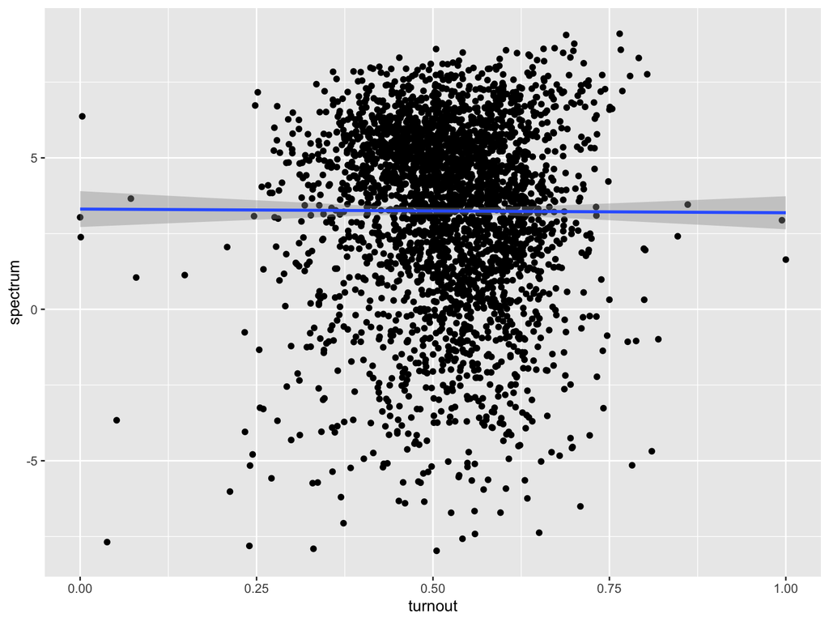

```r
library(ggplot2)
ggplot(df, aes(turnout, spectrum)) +
  geom_point() +
  geom_smooth(method='lm')
```

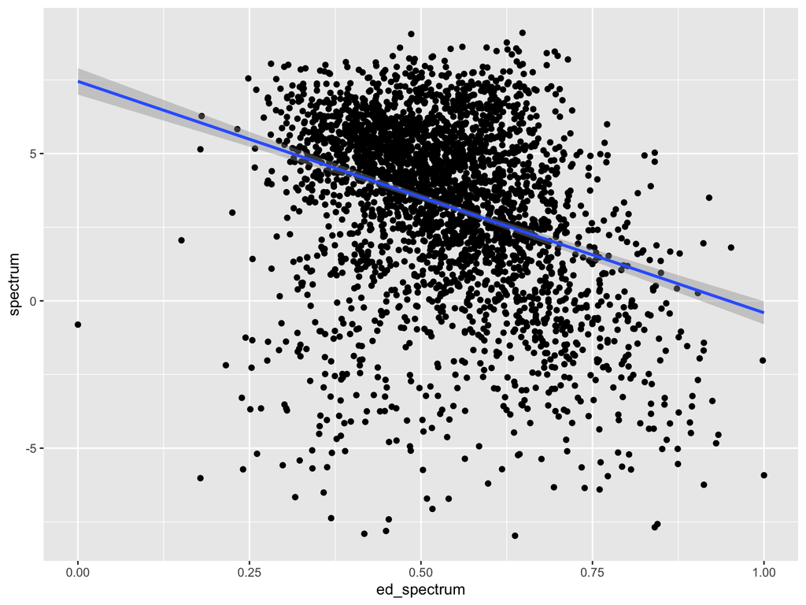

```r
ggplot(df, aes(ed_spectrum, spectrum)) +
  geom_point() +
  geom_smooth(method='lm')
```

# Visualizing the Model

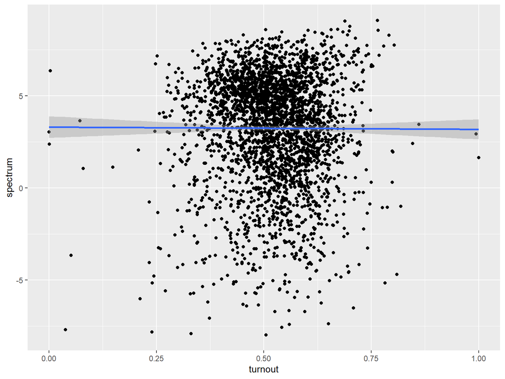

```r
library(ggplot2)
ggplot(df, aes(turnout, spectrum)) +
  geom_point() +
  geom_smooth(method='lm')
```

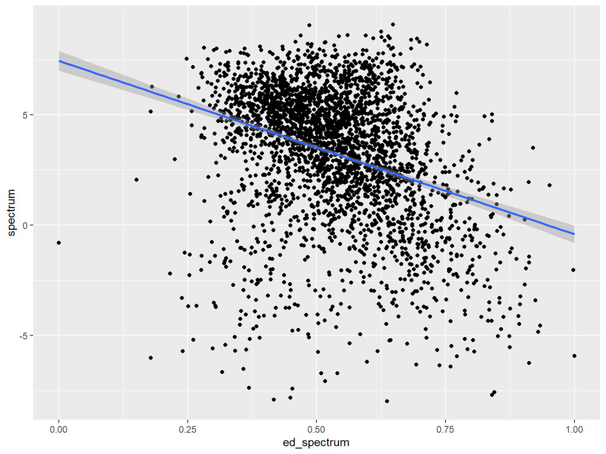

```r
ggplot(df, aes(ed_spectrum, spectrum)) +
  geom_point() +
  geom_smooth(method='lm')
```

# Working with Discrete Predictors and Dealing with Multicollinearity

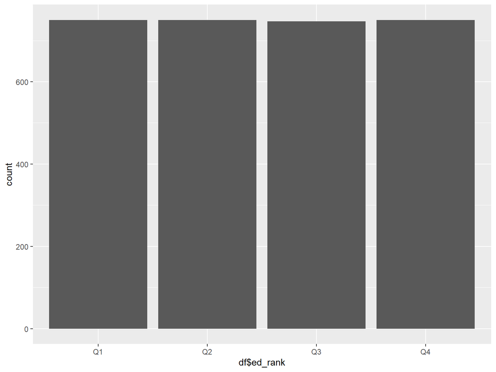

```r
df$ed_percentile <- percent_rank(df$ed_spectrum)
df$ed_rank <- ifelse(df$ed_percentile < 0.25, 'Q1',
                     ifelse(df$ed_percentile >=0.25 & df$ed_percentile < 0.5, 'Q2',
                            ifelse(df$ed_percentile >=0.5 & df$ed_percentile < 0.75, 'Q3','Q4')))

ggplot(df) +
  geom_bar(aes(df$ed_rank))
```

```r
df$edRank_Q1 <- ifelse(df$ed_rank == 'Q1',1,0)
df$edRank_Q2 <- ifelse(df$ed_rank == 'Q2',1,0)
df$edRank_Q3 <- ifelse(df$ed_rank == 'Q3',1,0)
df$edRank_Q4 <- ifelse(df$ed_rank == 'Q4',1,0)

model <- lm(spectrum ~
              edRank_Q1 +
              edRank_Q2 +
              edRank_Q3 +
              edRank_Q4
            , df)
summ(model)
```

| Observations | 2997 |
| --- | --- |
| Dependent variable | spectrum |
| Type | OLS linear regression |

| F(3,2993) | 130.16 |
| --- | --- |
| R² | 0.12 |
| Adj. R² | 0.11 |

|  | Est. | S.E. | t val. | p |
| --- | --- | --- | --- | --- |
| (Intercept) | 1.48 | 0.10 | 14.26 | 0.00 |
| edRank_Q1 | 2.42 | 0.15 | 16.49 | 0.00 |
| edRank_Q2 | 2.49 | 0.15 | 16.93 | 0.00 |
| edRank_Q3 | 2.15 | 0.15 | 14.61 | 0.00 |
| edRank_Q4 | NA | NA | NA | NA |

Standard errors: OLS

```r
library(olsrr)
ols_coll_diag(model)
```

```
## Tolerance and Variance Inflation Factor
## ---------------------------------------
##   Variables Tolerance VIF
## 1 edRank_Q1         0 Inf
## 2 edRank_Q2         0 Inf
## 3 edRank_Q3         0 Inf
## 4 edRank_Q4         0 Inf
##
##
## Eigenvalue and Condition Index
## ------------------------------
##     Eigenvalue Condition Index    intercept    edRank_Q1    edRank_Q2
## 1 2.000000e+00    1.000000e+00 5.552943e-29 5.552943e-29 5.552943e-29
## 2 1.000000e+00    1.414214e+00 0.000000e+00 1.311463e-28 2.167248e-28
## 3 1.000000e+00    1.414214e+00 4.578094e-56 5.309619e-28 3.190301e-28
## 4 1.000000e+00    1.414214e+00 0.000000e+00 3.356534e-30 1.297098e-28
## 5 1.332268e-15    3.874532e+07 1.000000e+00 1.000000e+00 1.000000e+00
##      edRank_Q3    edRank_Q4
## 1 5.552943e-29 5.552943e-29
## 2 1.005555e-29 5.296960e-28
## 3 3.697273e-29 7.656287e-31
## 4 6.220010e-28 1.350031e-28
## 5 1.000000e+00 1.000000e+00
```

```r
model <- lm(spectrum ~ turnout + ed_rank, df)
summ(model)
```

| Observations | 2997 |
| --- | --- |
| Dependent variable | spectrum |
| Type | OLS linear regression |

| F(4,2992) | 105.86 |
| --- | --- |
| R² | 0.12 |
| Adj. R² | 0.12 |

|  | Est. | S.E. | t val. | p |
| --- | --- | --- | --- | --- |
| (Intercept) | 2.45 | 0.29 | 8.50 | 0.00 |
| turnout | 3.13 | 0.58 | 5.41 | 0.00 |
| ed_rankQ2 | -0.08 | 0.15 | -0.54 | 0.59 |
| ed_rankQ3 | -0.54 | 0.15 | -3.47 | 0.00 |
| ed_rankQ4 | -2.72 | 0.16 | -17.40 | 0.00 |

Standard errors: OLS

```r
ols_coll_diag(model)
```

```
## Tolerance and Variance Inflation Factor
## ---------------------------------------
##   Variables Tolerance      VIF
## 1   turnout 0.8501279 1.176294
## 2 ed_rankQ2 0.6452925 1.549685
## 3 ed_rankQ3 0.6014157 1.662743
## 4 ed_rankQ4 0.5821724 1.717704
##
##
## Eigenvalue and Condition Index
## ------------------------------
##   Eigenvalue Condition Index    intercept      turnout   ed_rankQ2  ed_rankQ3
## 1 2.82199611        1.000000 3.888926e-03 3.468998e-03 0.017059397 0.01702395
## 2 1.00060441        1.679372 1.008592e-05 8.555551e-06 0.311701543 0.02047379
## 3 1.00000000        1.679880 0.000000e+00 2.008384e-30 0.018915441 0.27865687
## 4 0.16183072        4.175877 3.930468e-02 2.130540e-02 0.647503368 0.64050909
## 5 0.01556876       13.463291 9.567963e-01 9.752170e-01 0.004820251 0.04333631
##    ed_rankQ4
## 1 0.01691442
## 2 0.13494774
## 3 0.15003728
## 4 0.63458779
## 5 0.06351277
```